# Ford Bike Trips Dataset - (2/2019)

## by Belal Abdelnasser

## Investigation Overview

> This Dataset is for Ford Bikes and contain information about trips in Feb 2019. The structure of data is as follows:
> - duration_sec
> - start_time | 183412 non-null object
> - end_time | 183412 non-null object
> - start_station_id | 183215 non-null float64
> - start_station_name | 183215 non-null object
> - start_station_latitude | 183412 non-null float64
> - start_station_longitude | 183412 non-null float64
> - end_station_id | 183215 non-null float64
> - end_station_name | 183215 non-null object
> - end_station_latitude | 183412 non-null float64
> - end_station_longitude | 183412 non-null float64
> - bike_id | 183412 non-null int64
> - user_type | 183412 non-null object
> - member_birth_year | 175147 non-null float64
> - member_gender | 175147 non-null object
> - bike_share_for_all_trip | 183412 non-null object dtypes: float64(7), int64(2), object(7)

### We Need Some Data Wrangling Steps.

- Change start_time and end_time column data type to datetime
- Convert duration_sec to duration_hour
- Change user_type from str to category
- Change ids columns to str
- Drop NANs

## Univariant Visuals

### Subscribers to Customers ratio.

> - It's obvious that the Subscriber type is much more than Customer Type

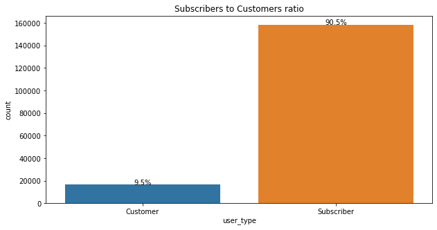

### Bike sharing Trips Vs Non-sharing

> - Bike Sharing all the trip is signficanlly small compared to Non-shared Trips

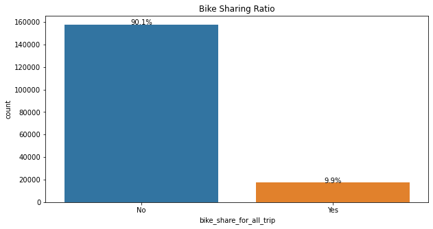

### Duration disribution.

> - Distribution of trips duration is Right skewed with mean equal 704.
> - There are alot of outliers

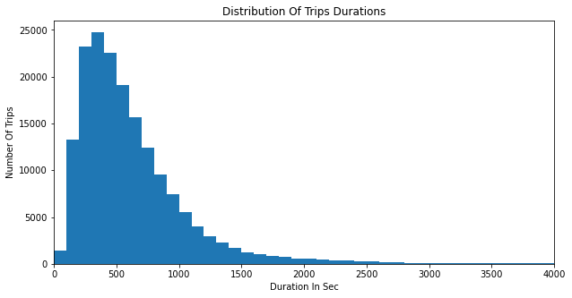

### Feature Engineering

> We need to do some transformations.
> - Create (Age) new feature from birth data column
> - Create month, weekday, hour and trip columns from start_time column.

### Relative frequency of trips per day and per hour

> - Bike Trips increase in Weekdays and decrease in weekends
> - Most trips are between 7:00 AM and 8:00 PM

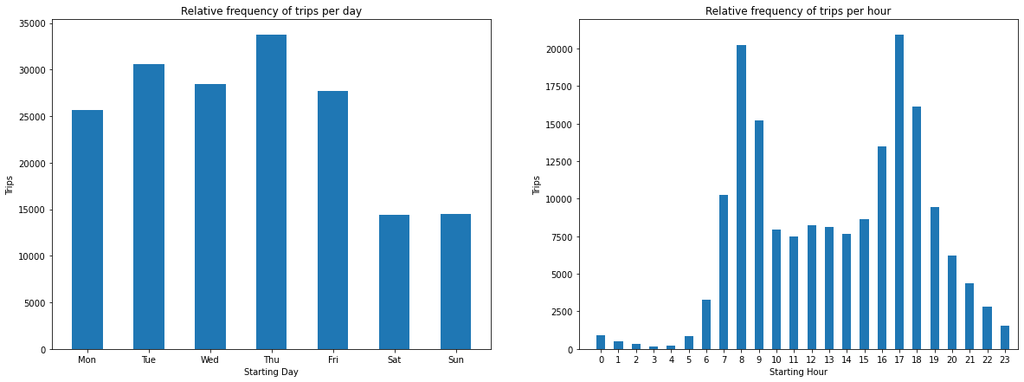